# Economic Outlook Report

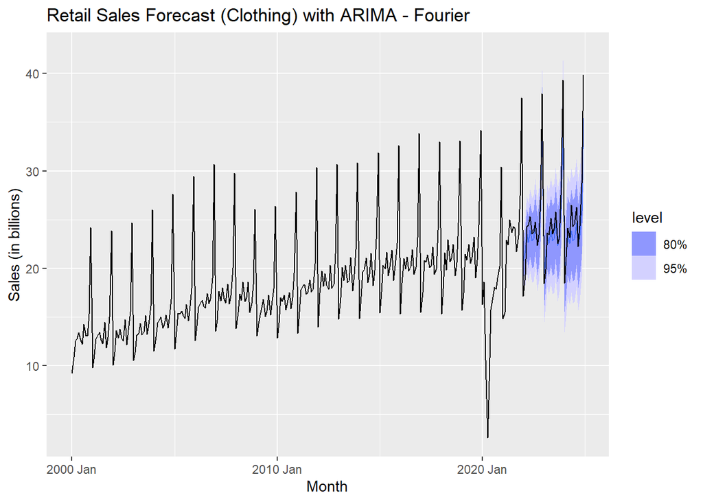

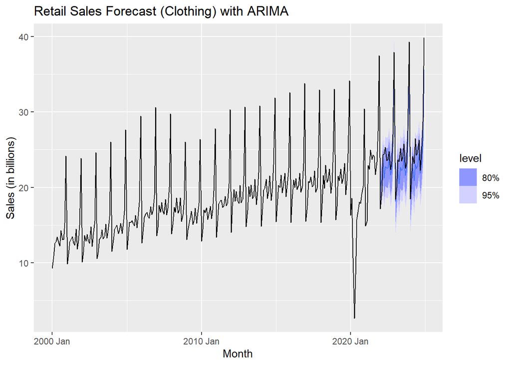

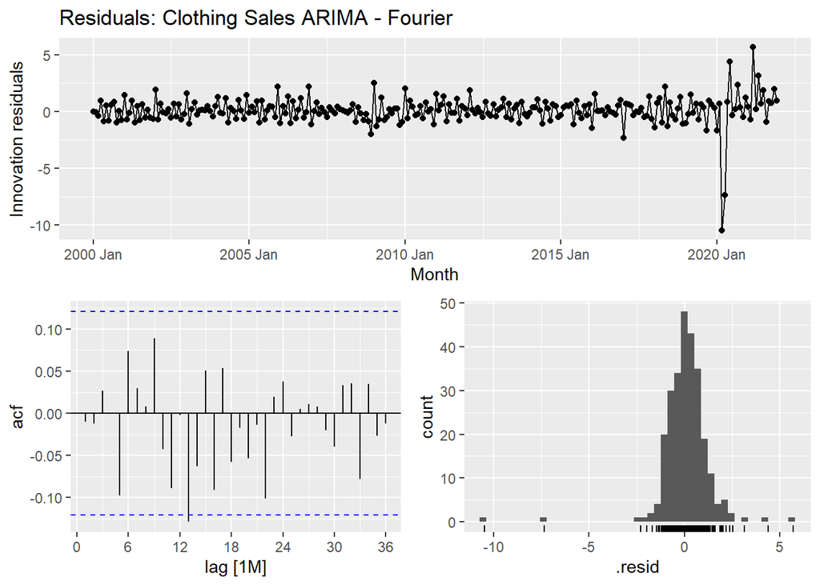

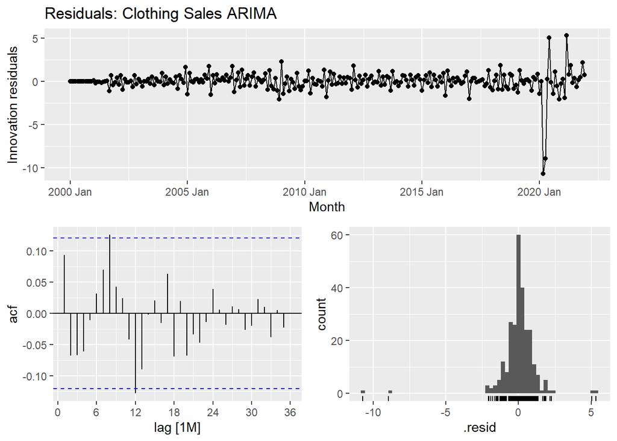

```
# A tibble: 4 × 5
  .model         .type     RMSE   MAE  MAPE
  <chr>          <chr>    <dbl> <dbl> <dbl>
1 arima_fourier6 Training  1.23 0.753  5.38
2 arima1         Training  1.22 0.654  4.88
3 arima_fourier6 Test      1.70 1.30   5.11
4 arima1         Test      2.01 1.71   6.67
```

```
# A tibble: 2 × 3
  .model         lb_stat lb_pvalue
  <chr>            <dbl>     <dbl>
1 arima_fourier6    4.58    0.802
2 arima1           11.7     0.0386
```

To assess the reliability of the top two clothing sales forecasting models arima1 (standard ARIMA) and arima_fourier6 (ARIMA with Fourier terms capturing seasonality), I examined their residual behavior and conducted Ljung-Box tests.

Residual Behavior:

- Both models show residuals centered around zero, indicating unbiased forecasts.
- The arima_fourier6 model exhibits slightly tighter dispersion and fewer large residuals, suggesting better stability over time.
- Histogram plots of residuals are approximately symmetric and bell-shaped for both models, supporting normality assumptions.

Autocorrelation (ACF):

Ljung-Box Test (lag = 8):

- arima_fourier6: p-value = 0.80 → Fail to reject the null hypothesis of white noise; residuals are independently distributed.
- arima1: p-value = 0.039 → Slightly below 0.05 threshold; indicates possible autocorrelation in residuals, suggesting the model may not have captured all the structure in the data.

While both models fit the data reasonably well, arima_fourier6 clearly passes the white noise test and displays better-behaved residuals. Therefore, ARIMA with Fourier terms (K=6) is the preferred model for forecasting clothing sales, as it handles seasonality effectively and provides cleaner residuals.

### Furniture and Home Furnishings Stores

#### Train - Test Split

I split the dataset into training and test sets. All data before January 2022 was used for training, while data from January 2022 onwards was reserved for testing. This setup allows for an honest evaluation of the forecasting models’ ability to generalize.

I also visualized the training data across the three variables to observe any discrepancies in trends and seasonality, which helped validate the relationships among these features before fitting time series models.

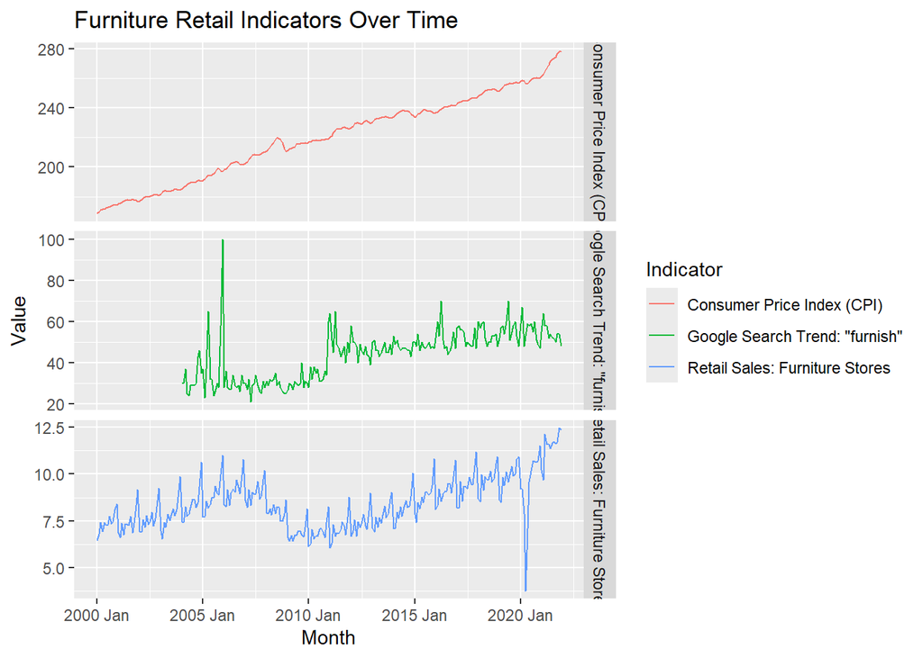

Retail Sales exhibit strong seasonality with an upward trend, sharply rising after pandemic.

#### Model Fitting

```
# A mable: 10 x 2
# Key:     Model name [10]
   `Model name`                                   Orders
   <chr>                                         <model>
 1 fourier6                                       <TSLM>
 2 ets                                      <ETS(A,N,A)>
 3 arima012011                 <ARIMA(0,1,2)(0,1,1)[12]>
 4 arima210011                 <ARIMA(2,1,0)(0,1,1)[12]>
 5 arima210110                 <ARIMA(2,1,0)(1,1,0)[12]>
 6 stepwise                    <ARIMA(1,0,2)(0,1,1)[12]>
 7 arima1                      <ARIMA(1,0,2)(0,1,1)[12]>
 8 arima_cpi      <LM w/ ARIMA(1,0,2)(0,1,1)[12] errors>
 9 arima_google   <LM w/ ARIMA(0,1,0)(1,0,0)[12] errors>
10 arima_fourier6            <LM w/ ARIMA(0,1,2) errors>
```

##### AIC Comparison

```
# A tibble: 10 × 6
   .model         sigma2 log_lik    AIC   AICc    BIC
   <chr>           <dbl>   <dbl>  <dbl>  <dbl>  <dbl>
 1 fourier6        1.03    -372.   23.5   25.2   73.6
 2 arima_fourier6  0.185   -145.  318.   320.   368.
 3 arima_cpi       0.194   -155.  323.   323.   344.
 4 arima012011     0.199   -159.  326.   326.   340.
 5 stepwise        0.198   -159.  327.   327.   345.
 6 arima1          0.198   -159.  327.   327.   345.
 7 arima210011     0.205   -163.  335.   335.   349.
 8 arima210110     0.245   -182.  372.   372.   386.
 9 arima_google    0.348   -217.  440.   440.   450.
10 ets             0.210   -523. 1076.  1078.  1130.
```

I fitted a combination of models including traditional ARIMA configurations, ETS, Fourier-based regression (to capture seasonality), and ARIMA models with external regressors like the Consumer Price Index (CPI) and Google Trends search interest for “furnish”.

From the AICc table:

Models incorporating seasonal structures through Fourier terms provide the best fit for the furniture sales data. External signals like CPI help to some extent, but Google Trends did not contribute significantly in this case. ETS, which performs well on simpler series, falls short here due to the complex patterns likely influenced by macroeconomic and seasonal effects.

###### Forecasts: Top 6 Models Ranked by AICc

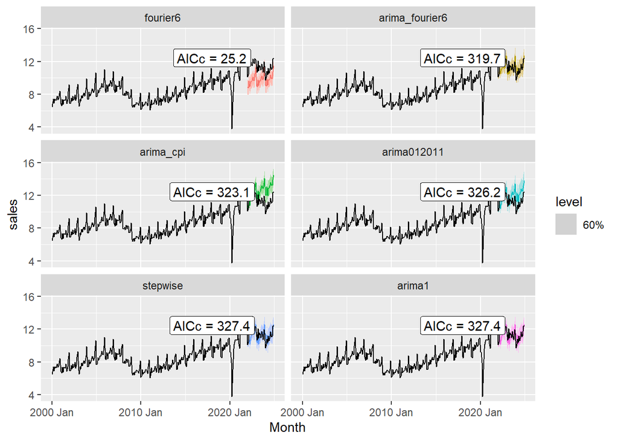

##### Training Data RMSE

```
# A tibble: 10 × 5
   .model         .type     RMSE   MAE  MAPE
   <chr>          <chr>    <dbl> <dbl> <dbl>
 1 arima_fourier6 Training 0.419 0.258  3.26
 2 arima_cpi      Training 0.426 0.261  3.26
 3 stepwise       Training 0.431 0.264  3.29
 4 arima1         Training 0.431 0.264  3.29
 5 arima012011    Training 0.432 0.263  3.29
 6 arima210011    Training 0.439 0.274  3.41
 7 ets            Training 0.446 0.261  3.30
 8 arima210110    Training 0.479 0.315  3.86
 9 arima_google   Training 0.649 0.368  4.48
10 fourier6       Training 0.992 0.773  9.64
```

I evaluated all models based on training RMSE to compare how well they fit the historical data.

- arima_fourier6 had the lowest RMSE (0.419), showing strong fit by combining ARIMA with seasonal patterns.
- arima_cpi (RMSE = 0.426) indicates CPI is a valuable predictor for furniture sales.
- Traditional ARIMA models like arima1 and stepwise performed reasonably well (~0.431 RMSE).
- ETS and basic ARIMA variants had slightly higher errors, suggesting weaker fit.
- arima_google showed poor performance (RMSE = 0.648), indicating that Google Trends for furniture may not align well with actual sales.
- fourier6 alone performed the worst (RMSE = 0.992), lacking ARIMA’s ability to handle complex patterns.

Combining ARIMA with seasonal (Fourier) or economic (CPI) indicators improves model accuracy for furniture sales.

###### Forecasts: Top 6 Models Ranked by Training Data RMSE

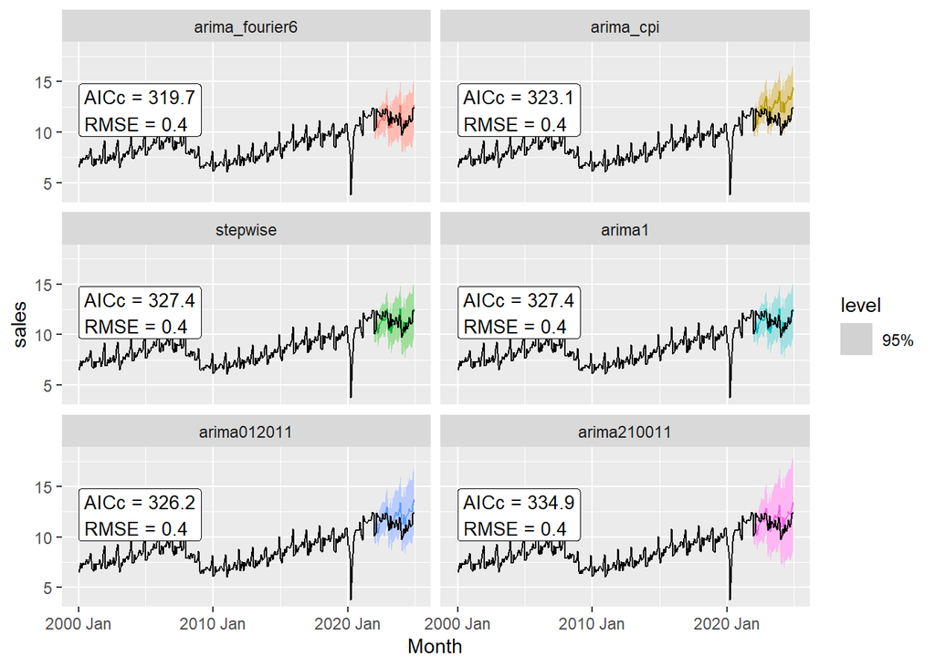

##### Test Data RMSE

```
# A tibble: 10 × 5
   .model         .type  RMSE   MAE  MAPE
   <chr>          <chr> <dbl> <dbl> <dbl>
 1 arima_fourier6 Test  0.547 0.422  3.67
 2 arima1         Test  0.575 0.447  3.92
 3 stepwise       Test  0.575 0.447  3.92
 4 ets            Test  0.682 0.540  4.65
 5 arima210011    Test  0.825 0.682  6.05
 6 arima012011    Test  0.957 0.779  6.95
 7 arima_cpi      Test  1.49  1.30  11.7
 8 fourier6       Test  1.66  1.55  13.5
 9 arima_google   Test  1.78  1.58  14.3
10 arima210110    Test  1.80  1.49  13.2
```

I evaluated model performance on the test set (2022–2024) using RMSE.

- arima_fourier6 had the lowest test RMSE (0.547), indicating strong generalization by blending seasonality with ARIMA structure.
- arima1 and stepwise (both RMSE = 0.575) also performed well, confirming ARIMA’s reliability without external regressors.
- ETS showed moderate accuracy (RMSE = 0.682), better than most ARIMA variants with fixed orders.
- arima_cpi and arima_google had high RMSEs (1.49 and 1.78), suggesting external regressors like CPI and Google Trends did not generalize well for furniture.
- Basic fourier6 (RMSE = 1.66) failed to capture complex dynamics without ARIMA components.

###### Forecasts: Top 6 Models Ranked by Test Data RMSE

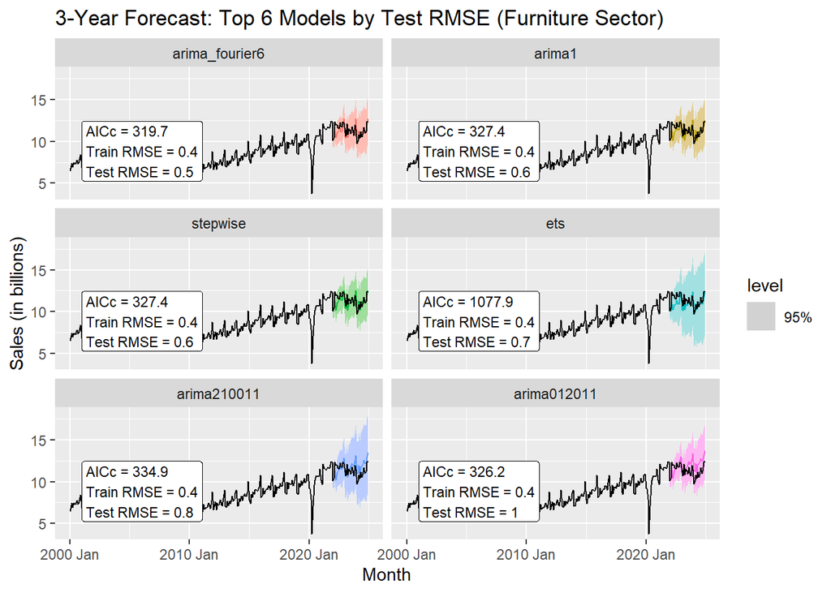

To visualize how the leading models behave in practice, I generated forecasts from the top two performers based on Test RMSE — arima_fourier6 and arima1. These were not selected to compete, but to provide a clearer picture of how well each model captures retail sales patterns. I also assessed their residuals and Ljung-Box statistics to confirm model adequacy.

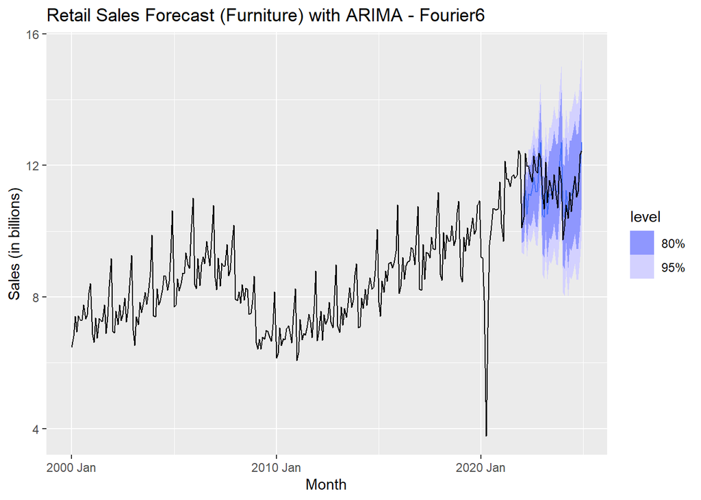

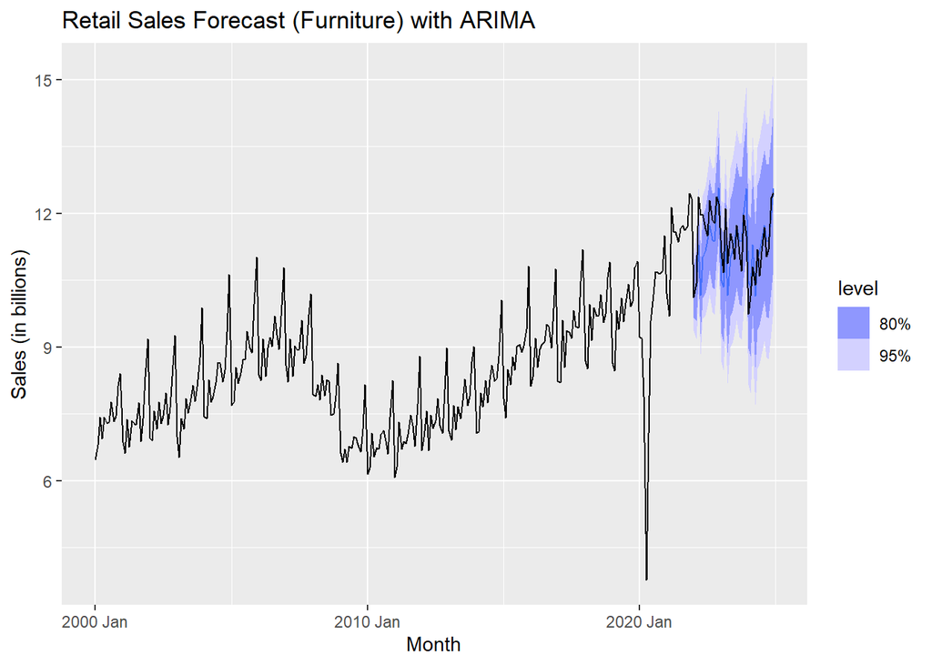

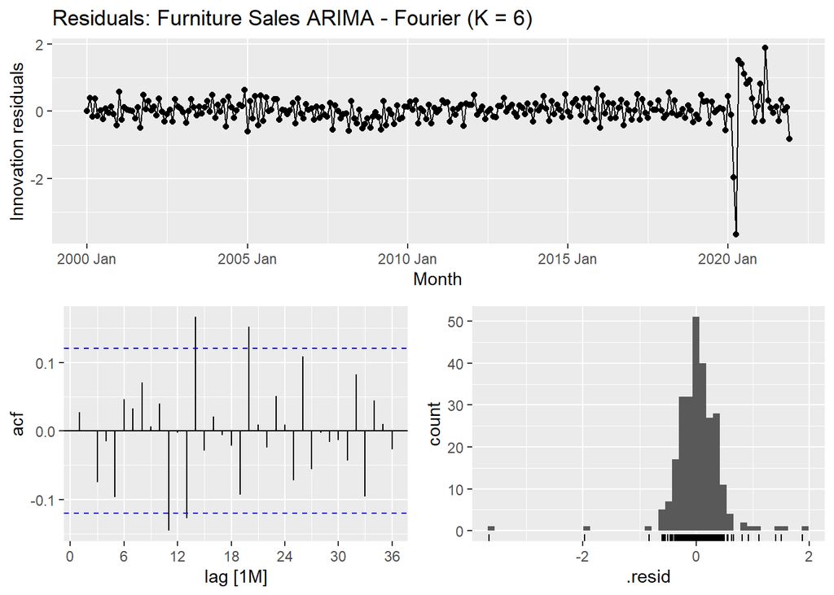

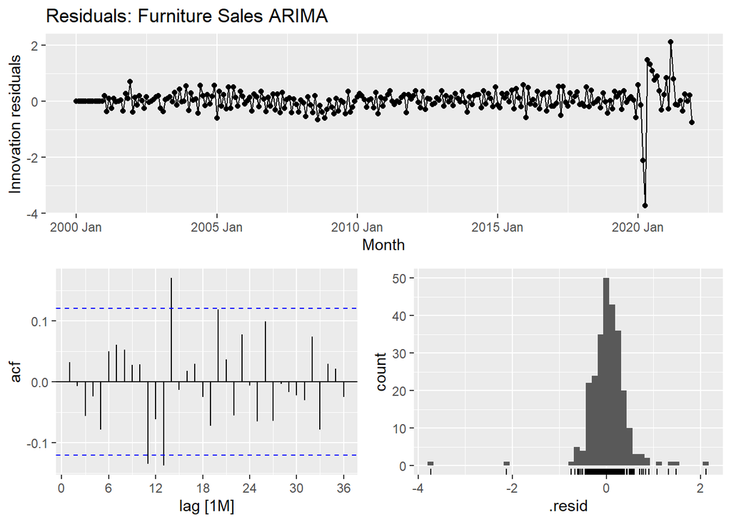

```
# A tibble: 4 × 5
  .model         .type     RMSE   MAE  MAPE
  <chr>          <chr>    <dbl> <dbl> <dbl>
1 arima_fourier6 Training 0.419 0.258  3.26
2 arima1         Training 0.431 0.264  3.29
3 arima_fourier6 Test     0.547 0.422  3.67
4 arima1         Test     0.575 0.447  3.92
```

```
# A tibble: 2 × 3
  .model         lb_stat lb_pvalue
  <chr>            <dbl>     <dbl>
1 arima_fourier6    6.57     0.583
2 arima1            5.41     0.368
```

Both models show good residual behavior:

- Residuals are centered around zero for both models, with no clear patterns—suggesting a good fit.
- ACF plots indicate that most lags fall within 95% bounds, implying residuals are not autocorrelated.
- Histograms appear roughly bell-shaped, supporting the assumption of normality.
- Ljung-Box test (lag = 8):
- arima_fourier6: p = 0.583
- arima1: p = 0.368
- Both p-values are high, confirming that residuals behave like white noise.

While both models are valid, arima_fourier6 outperforms arima1 in both training and test RMSE, making it the preferred model for forecasting furniture sales.

## Key Findings

Retail Trade & Food Services:

- ARIMA with Google Trends (“restaurants”) was the top performer on both AICc and test RMSE. This model captured consumer interest effectively, showing strong predictive power for sales.

Clothing Stores:

- ARIMA1 (standard) and Fourier-enhanced ARIMA yielded the best generalization to the test set. Google Trends for “clothing” did not improve forecasts as significantly, and CPI models performed inconsistently.

Furniture & Home Furnishings Stores:

- ARIMA + Fourier terms was the best model across training and test sets. Google Trends for “furnish” and CPI regressors underperformed, indicating limited external signal strength for this category.

CPI & Google Trends:

- While Google Trends was highly effective for food-related sales, its relevance varied by category. CPI improved model fit modestly in training but often failed to generalize well to test data.

## Conclusion

The analysis demonstrates that model performance is highly domain-specific. While ARIMA models with external regressors like Google Trends excel in categories with strong online consumer behavior (e.g., food services), Fourier terms and plain ARIMA models remain robust choices in more stable or less search-driven domains like furniture.

This analysis illustrates the value of combining traditional time series modeling with publicly available external signals. When carefully aligned by domain, such features can enhance forecasting accuracy and generate actionable insights into U.S. consumer market trends.

## Limitations and Next Steps

- Future work could include more granular data (e.g., weekly sales).
- Explore VAR models or machine learning methods.
- Expand Google Trends coverage to include product-level terms or broader categories.